# 02_mmingalov

### Задание

Обозначения:

p - глубина истории, сколько измерений назад учитываем в моделях

h - горизонт прогноза , на сколько измерений вперед смотрим при моделировании (как далеко предсказываем)

а) Изменение температуры за окном :).

б) Количество денег, которые тратят покупатели в интернет магазине.

в) Вес растущего котенка.

г) Прирост объема деревьев в лесу от времени

```python
%matplotlib inline
import matplotlib.pyplot as plt

import numpy as np
import pandas as pd
import seaborn as sns


from sklearn.metrics import mean_squared_error

import os
```

```python
path_brent = 'my_BRENT2019.csv'
brent_data = pd.read_csv(path_brent,sep = ',', index_col=[0], parse_dates=[0])
brent_data['index'] = brent_data.index
brent_data.head()
```

| Дата | Значение | year | month | dayofmonth | quarter | dayofyear | weekofyear | dayofweek | is_holiday | is_prev_holiday | is_next_holiday | index |
| --- | --- | --- | --- | --- | --- | --- | --- | --- | --- | --- | --- | --- |
| 2010-09-01 | 76.37 | 2010 | 9 | 1 | 3 | 244 | 35 | 2 | 0 | 0 | 0 | 2010-09-01 |
| 2010-09-02 | 76.89 | 2010 | 9 | 2 | 3 | 245 | 35 | 3 | 0 | 0 | 0 | 2010-09-02 |
| 2010-09-03 | 76.57 | 2010 | 9 | 3 | 3 | 246 | 35 | 4 | 0 | 0 | 0 | 2010-09-03 |
| 2010-09-04 | 76.62 | 2010 | 9 | 4 | 3 | 247 | 35 | 5 | 0 | 0 | 0 | 2010-09-04 |
| 2010-09-05 | 76.63 | 2010 | 9 | 5 | 3 | 248 | 35 | 6 | 0 | 1 | 0 | 2010-09-05 |

```python
brent_data.describe()
```

|  | Значение | year | month | dayofmonth | quarter | dayofyear | weekofyear | dayofweek | is_holiday | is_prev_holiday | is_next_holiday |
| --- | --- | --- | --- | --- | --- | --- | --- | --- | --- | --- | --- |
| count | 2667.000000 | 2667.000000 | 2667.00000 | 2667.000000 | 2667.000000 | 2667.000000 | 2667.000000 | 2667.000000 | 2667.000000 | 2667.000000 | 2667.000000 |
| mean | 81.533547 | 2014.661042 | 6.51706 | 15.715786 | 2.505062 | 182.901762 | 26.486689 | 2.537308 | 0.027747 | 0.026997 | 0.029621 |
| std | 26.349469 | 2.663525 | 3.43026 | 8.780275 | 1.112684 | 104.741067 | 14.935147 | 1.894937 | 0.164277 | 0.162104 | 0.169572 |
| min | 27.850000 | 2010.000000 | 1.00000 | 1.000000 | 1.000000 | 2.000000 | 1.000000 | 0.000000 | 0.000000 | 0.000000 | 0.000000 |
| 25% | 56.840000 | 2012.000000 | 4.00000 | 8.000000 | 2.000000 | 92.000000 | 14.000000 | 1.000000 | 0.000000 | 0.000000 | 0.000000 |
| 50% | 77.710000 | 2015.000000 | 7.00000 | 16.000000 | 3.000000 | 183.000000 | 27.000000 | 2.000000 | 0.000000 | 0.000000 | 0.000000 |
| 75% | 108.190000 | 2017.000000 | 9.00000 | 23.000000 | 3.000000 | 273.000000 | 39.000000 | 4.000000 | 0.000000 | 0.000000 | 0.000000 |
| max | 126.900000 | 2019.000000 | 12.00000 | 31.000000 | 4.000000 | 366.000000 | 53.000000 | 6.000000 | 1.000000 | 1.000000 | 1.000000 |

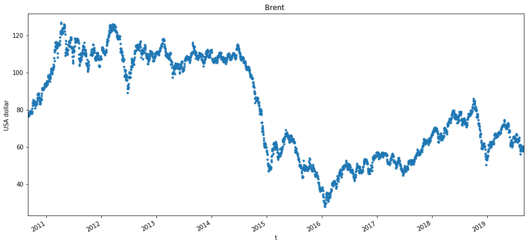

```python
_ = brent_data['Значение'].plot( style='.', figsize=( 15, 7 ), title='Brent ')
plt.ylabel('USA dollar')
plt.xlabel('t')
```

### сделать анализ пропусков и больше чем 2-х дневные заполнить

например:

- 2010-12-10 00:00:00
- 2010-12-13 00:00:00 разница 3 дня, т.е. более чем 2-х дневный пропуск

```python
brent_data['Значение'].isnull().sum()
```

```
0
```

```python
#brent_data.index[1:]
```

```python
#сделаем список словарей, описывающих пропуски
list = []
for id, item in enumerate(brent_data['index'][1:]):
    diff = (brent_data['index'][id]-brent_data['index'][id-1]).days
    if (diff>2):
        #print(brent_data['index'][id-1],brent_data['index'][id],diff)
        list.append(
            {
                'date1': brent_data['index'][id-1],
                'value1': brent_data['Значение'][id-1],
                'date2': brent_data['index'][id],
                'value2': brent_data['Значение'][id],
                'days_diff': diff,
                'value_diff': brent_data['Значение'][id] - brent_data['Значение'][id-1]
            }
        )
print('Всего разрывов разной протяженности по условию:',len(list))
```

```
Всего разрывов разной протяженности по условию: 120
```

```python
#brent_data_ = brent_data
from datetime import timedelta
```

```python
#для пропусков будем проставлять вычисляемые значения с учетом рассчитанного равномерного шага
index_list = []
value_list = []
for i in range(len(list)):
    vd = list[i]['value_diff']
    dd = list[i]['days_diff']
    d1 = list[i]['date1']
    v1 = list[i]['value1']
    v2 = list[i]['value2']
    step = vd/dd
    #print(list[i]['value_diff'],list[i]['days_diff'],step)
    for j in range(dd-1):
        t1 = list[i]['date1']+timedelta(1+j)
        t2 = list[i]['value1']+(j+1)*step
        index_list.append(t1)
        value_list.append(t2)
        #print(d1,(v1,v2),t1,t2)
```

```python
#сформируем добавочный dataframe
df_data = pd.DataFrame(index = pd.to_datetime(pd.Series(index_list)), columns =['Значение'] , data = value_list)
df_data['index'] = df_data.index
```

```python
from pandas.tseries.holiday import USFederalHolidayCalendar as calendar
#from datetime import timedelta
one_day = timedelta(days=1)
cal = calendar()
#инициализировали объект календарь

df_data['year'] = df_data['index'].dt.year
df_data['month'] = df_data['index'].dt.month
df_data['dayofmonth'] = df_data['index'].dt.day
df_data['quarter'] = df_data['index'].dt.quarter
df_data['dayofyear'] = df_data['index'].dt.dayofyear
df_data['weekofyear'] = df_data['index'].dt.weekofyear
df_data['dayofweek'] = df_data['index'].dt.dayofweek
df_data['is_holiday'] = (df_data['index'].isin([d.date() for d in cal.holidays()])).astype(int)
df_data['is_prev_holiday'] = (df_data['index'].isin([( d.date() - one_day ) for d in cal.holidays()])).astype(int)
df_data['is_next_holiday'] = (df_data['index'].isin([( d.date() + one_day ) for d in cal.holidays()])).astype(int)
```

```python
#df_data['index'].isin([d.date() for d in cal.holidays()])
```

```python
df_data.describe()
```

|  | Значение | year | month | dayofmonth | quarter | dayofyear | weekofyear | dayofweek | is_holiday | is_prev_holiday | is_next_holiday |
| --- | --- | --- | --- | --- | --- | --- | --- | --- | --- | --- | --- |
| count | 258.000000 | 258.000000 | 258.000000 | 258.000000 | 258.000000 | 258.000000 | 258.000000 | 258.000000 | 258.000000 | 258.000000 | 258.000000 |
| mean | 63.607810 | 2014.903101 | 6.736434 | 16.158915 | 2.600775 | 190.155039 | 28.248062 | 5.143411 | 0.034884 | 0.069767 | 0.023256 |
| std | 27.098057 | 1.715774 | 3.559433 | 8.964800 | 1.143208 | 110.017293 | 15.686387 | 1.225053 | 0.183842 | 0.255250 | 0.151008 |
| min | 29.256667 | 2010.000000 | 1.000000 | 1.000000 | 1.000000 | 1.000000 | 1.000000 | 0.000000 | 0.000000 | 0.000000 | 0.000000 |
| 25% | 46.084167 | 2015.000000 | 4.000000 | 9.000000 | 2.000000 | 98.500000 | 15.000000 | 5.000000 | 0.000000 | 0.000000 | 0.000000 |
| 50% | 50.308333 | 2015.000000 | 7.000000 | 16.000000 | 3.000000 | 185.500000 | 28.000000 | 5.000000 | 0.000000 | 0.000000 | 0.000000 |
| 75% | 68.807500 | 2016.000000 | 10.000000 | 24.000000 | 4.000000 | 289.000000 | 42.000000 | 6.000000 | 0.000000 | 0.000000 | 0.000000 |
| max | 124.166667 | 2019.000000 | 12.000000 | 31.000000 | 4.000000 | 366.000000 | 53.000000 | 6.000000 | 1.000000 | 1.000000 | 1.000000 |

```python
brent_data_ = pd.concat([brent_data, df_data], axis=0, ignore_index=False)
```

```python
brent_data_.describe()
```

|  | dayofmonth | dayofweek | dayofyear | is_holiday | is_next_holiday | is_prev_holiday | month | quarter | weekofyear | year | Значение |
| --- | --- | --- | --- | --- | --- | --- | --- | --- | --- | --- | --- |
| count | 2925.000000 | 2925.000000 | 2925.000000 | 2925.000000 | 2925.000000 | 2925.000000 | 2925.000000 | 2925.000000 | 2925.000000 | 2925.000000 | 2925.000000 |
| mean | 15.754872 | 2.767179 | 183.541538 | 0.028376 | 0.029060 | 0.030769 | 6.536410 | 2.513504 | 26.642051 | 2014.682393 | 79.952405 |
| std | 8.796048 | 1.988033 | 105.217702 | 0.166073 | 0.168003 | 0.172721 | 3.441785 | 1.115541 | 15.008459 | 2.594582 | 26.896574 |
| min | 1.000000 | 0.000000 | 1.000000 | 0.000000 | 0.000000 | 0.000000 | 1.000000 | 1.000000 | 1.000000 | 2010.000000 | 27.850000 |
| 25% | 8.000000 | 1.000000 | 93.000000 | 0.000000 | 0.000000 | 0.000000 | 4.000000 | 2.000000 | 14.000000 | 2012.000000 | 55.470000 |
| 50% | 16.000000 | 3.000000 | 183.000000 | 0.000000 | 0.000000 | 0.000000 | 7.000000 | 3.000000 | 27.000000 | 2015.000000 | 74.830000 |
| 75% | 23.000000 | 4.000000 | 275.000000 | 0.000000 | 0.000000 | 0.000000 | 10.000000 | 4.000000 | 40.000000 | 2017.000000 | 108.000000 |
| max | 31.000000 | 6.000000 | 366.000000 | 1.000000 | 1.000000 | 1.000000 | 12.000000 | 4.000000 | 53.000000 | 2019.000000 | 126.900000 |

```python
brent_data_
```

|  | dayofmonth | dayofweek | dayofyear | index | is_holiday | is_next_holiday | is_prev_holiday | month | quarter | weekofyear | year | Значение |
| --- | --- | --- | --- | --- | --- | --- | --- | --- | --- | --- | --- | --- |
| 2010-09-01 | 1 | 2 | 244 | 2010-09-01 | 0 | 0 | 0 | 9 | 3 | 35 | 2010 | 76.370000 |
| 2010-09-02 | 2 | 3 | 245 | 2010-09-02 | 0 | 0 | 0 | 9 | 3 | 35 | 2010 | 76.890000 |
| 2010-09-03 | 3 | 4 | 246 | 2010-09-03 | 0 | 0 | 0 | 9 | 3 | 35 | 2010 | 76.570000 |
| 2010-09-04 | 4 | 5 | 247 | 2010-09-04 | 0 | 0 | 0 | 9 | 3 | 35 | 2010 | 76.620000 |
| 2010-09-05 | 5 | 6 | 248 | 2010-09-05 | 0 | 0 | 1 | 9 | 3 | 35 | 2010 | 76.630000 |
| ... | ... | ... | ... | ... | ... | ... | ... | ... | ... | ... | ... | ... |
| 2018-01-01 | 1 | 0 | 1 | 2018-01-01 | 1 | 0 | 0 | 1 | 1 | 1 | 2018 | 66.645000 |
| 2018-03-30 | 30 | 4 | 89 | 2018-03-30 | 0 | 0 | 0 | 3 | 1 | 13 | 2018 | 69.403333 |
| 2018-03-31 | 31 | 5 | 90 | 2018-03-31 | 0 | 0 | 0 | 3 | 1 | 13 | 2018 | 69.456667 |
| 2019-04-19 | 19 | 4 | 109 | 2019-04-19 | 0 | 0 | 0 | 4 | 2 | 16 | 2019 | 72.090000 |
| 2019-04-20 | 20 | 5 | 110 | 2019-04-20 | 0 | 0 | 0 | 4 | 2 | 16 | 2019 | 72.170000 |

2925 rows × 12 columns

## Разрывы обработаны

```python
#делаем ресэмплинг на 3 дня исходного датафрейма с разрывами
brent_data_3d = brent_data.resample('3D').mean()
```

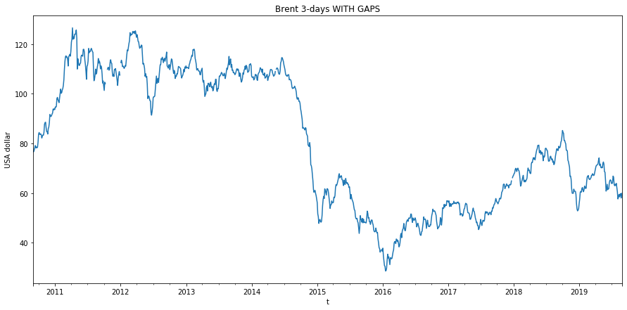

```python
_ = brent_data_3d['Значение'].plot( style='-', figsize=( 15, 7 ), title='Brent 3-days WITH GAPS')
plt.ylabel('USA dollar')
plt.xlabel('t')
plt.show()
```

```python
brent_data_
```

|  | dayofmonth | dayofweek | dayofyear | index | is_holiday | is_next_holiday | is_prev_holiday | month | quarter | weekofyear | year | Значение |
| --- | --- | --- | --- | --- | --- | --- | --- | --- | --- | --- | --- | --- |
| 2010-09-01 | 1 | 2 | 244 | 2010-09-01 | 0 | 0 | 0 | 9 | 3 | 35 | 2010 | 76.370000 |
| 2010-09-02 | 2 | 3 | 245 | 2010-09-02 | 0 | 0 | 0 | 9 | 3 | 35 | 2010 | 76.890000 |
| 2010-09-03 | 3 | 4 | 246 | 2010-09-03 | 0 | 0 | 0 | 9 | 3 | 35 | 2010 | 76.570000 |
| 2010-09-04 | 4 | 5 | 247 | 2010-09-04 | 0 | 0 | 0 | 9 | 3 | 35 | 2010 | 76.620000 |
| 2010-09-05 | 5 | 6 | 248 | 2010-09-05 | 0 | 0 | 1 | 9 | 3 | 35 | 2010 | 76.630000 |
| ... | ... | ... | ... | ... | ... | ... | ... | ... | ... | ... | ... | ... |
| 2018-01-01 | 1 | 0 | 1 | 2018-01-01 | 1 | 0 | 0 | 1 | 1 | 1 | 2018 | 66.645000 |
| 2018-03-30 | 30 | 4 | 89 | 2018-03-30 | 0 | 0 | 0 | 3 | 1 | 13 | 2018 | 69.403333 |
| 2018-03-31 | 31 | 5 | 90 | 2018-03-31 | 0 | 0 | 0 | 3 | 1 | 13 | 2018 | 69.456667 |
| 2019-04-19 | 19 | 4 | 109 | 2019-04-19 | 0 | 0 | 0 | 4 | 2 | 16 | 2019 | 72.090000 |
| 2019-04-20 | 20 | 5 | 110 | 2019-04-20 | 0 | 0 | 0 | 4 | 2 | 16 | 2019 | 72.170000 |

2925 rows × 12 columns

```python
#делаем ресэмплинг на 3 дня улучшенного датасета, БЕЗ РАЗРЫВОВ
brent_data_3d = brent_data_.resample('3D').mean()
brent_data_3d
```

|  | dayofmonth | dayofweek | dayofyear | is_holiday | is_next_holiday | is_prev_holiday | month | quarter | weekofyear | year | Значение |
| --- | --- | --- | --- | --- | --- | --- | --- | --- | --- | --- | --- |
| 2010-09-01 | 2.0 | 3.000000 | 245.0 | 0.000000 | 0.000000 | 0.000000 | 9.0 | 3.0 | 35.000000 | 2010.0 | 76.610000 |
| 2010-09-04 | 5.0 | 3.666667 | 248.0 | 0.333333 | 0.000000 | 0.333333 | 9.0 | 3.0 | 35.333333 | 2010.0 | 76.706667 |
| 2010-09-07 | 8.0 | 2.000000 | 251.0 | 0.000000 | 0.333333 | 0.000000 | 9.0 | 3.0 | 36.000000 | 2010.0 | 77.466667 |
| 2010-09-10 | 10.5 | 4.500000 | 253.5 | 0.000000 | 0.000000 | 0.000000 | 9.0 | 3.0 | 36.000000 | 2010.0 | 78.385000 |
| 2010-09-13 | 14.0 | 1.000000 | 257.0 | 0.000000 | 0.000000 | 0.000000 | 9.0 | 3.0 | 37.000000 | 2010.0 | 79.163333 |
| ... | ... | ... | ... | ... | ... | ... | ... | ... | ... | ... | ... |
| 2019-08-18 | 19.0 | 2.333333 | 231.0 | 0.000000 | 0.000000 | 0.000000 | 8.0 | 3.0 | 33.666667 | 2019.0 | 59.560000 |
| 2019-08-21 | 22.0 | 3.000000 | 234.0 | 0.000000 | 0.000000 | 0.000000 | 8.0 | 3.0 | 34.000000 | 2019.0 | 59.790000 |
| 2019-08-24 | 25.5 | 3.000000 | 237.5 | 0.000000 | 0.000000 | 0.000000 | 8.0 | 3.0 | 34.500000 | 2019.0 | 58.035000 |
| 2019-08-27 | 28.0 | 2.000000 | 240.0 | 0.000000 | 0.000000 | 0.000000 | 8.0 | 3.0 | 35.000000 | 2019.0 | 59.933333 |
| 2019-08-30 | 15.5 | 5.000000 | 243.0 | 0.000000 | 0.000000 | 0.500000 | 8.5 | 3.0 | 35.000000 | 2019.0 | 59.015000 |

1096 rows × 11 columns

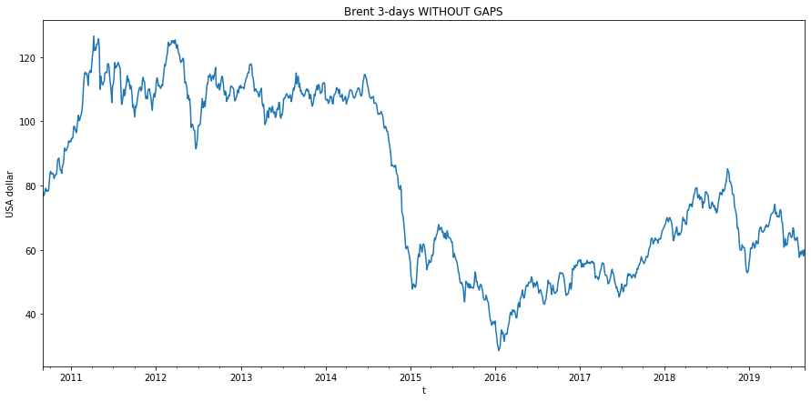

```python
_ = brent_data_3d['Значение'].plot( style='-', figsize=( 15, 7 ), title='Brent 3-days WITHOUT GAPS')
plt.ylabel('USA dollar')
plt.xlabel('t')
plt.show()
```

### здесь уже разрывов нет

brent_data_3d

```python
brent_data_3d['date']=brent_data_3d.index
brent_data_3d
```

|  | dayofmonth | dayofweek | dayofyear | is_holiday | is_next_holiday | is_prev_holiday | month | quarter | weekofyear | year | Значение | date |
| --- | --- | --- | --- | --- | --- | --- | --- | --- | --- | --- | --- | --- |
| 2010-09-01 | 2.0 | 3.000000 | 245.0 | 0.000000 | 0.000000 | 0.000000 | 9.0 | 3.0 | 35.000000 | 2010.0 | 76.610000 | 2010-09-01 |
| 2010-09-04 | 5.0 | 3.666667 | 248.0 | 0.333333 | 0.000000 | 0.333333 | 9.0 | 3.0 | 35.333333 | 2010.0 | 76.706667 | 2010-09-04 |
| 2010-09-07 | 8.0 | 2.000000 | 251.0 | 0.000000 | 0.333333 | 0.000000 | 9.0 | 3.0 | 36.000000 | 2010.0 | 77.466667 | 2010-09-07 |
| 2010-09-10 | 10.5 | 4.500000 | 253.5 | 0.000000 | 0.000000 | 0.000000 | 9.0 | 3.0 | 36.000000 | 2010.0 | 78.385000 | 2010-09-10 |
| 2010-09-13 | 14.0 | 1.000000 | 257.0 | 0.000000 | 0.000000 | 0.000000 | 9.0 | 3.0 | 37.000000 | 2010.0 | 79.163333 | 2010-09-13 |
| ... | ... | ... | ... | ... | ... | ... | ... | ... | ... | ... | ... | ... |
| 2019-08-18 | 19.0 | 2.333333 | 231.0 | 0.000000 | 0.000000 | 0.000000 | 8.0 | 3.0 | 33.666667 | 2019.0 | 59.560000 | 2019-08-18 |
| 2019-08-21 | 22.0 | 3.000000 | 234.0 | 0.000000 | 0.000000 | 0.000000 | 8.0 | 3.0 | 34.000000 | 2019.0 | 59.790000 | 2019-08-21 |
| 2019-08-24 | 25.5 | 3.000000 | 237.5 | 0.000000 | 0.000000 | 0.000000 | 8.0 | 3.0 | 34.500000 | 2019.0 | 58.035000 | 2019-08-24 |
| 2019-08-27 | 28.0 | 2.000000 | 240.0 | 0.000000 | 0.000000 | 0.000000 | 8.0 | 3.0 | 35.000000 | 2019.0 | 59.933333 | 2019-08-27 |
| 2019-08-30 | 15.5 | 5.000000 | 243.0 | 0.000000 | 0.000000 | 0.500000 | 8.5 | 3.0 | 35.000000 | 2019.0 | 59.015000 | 2019-08-30 |

1096 rows × 12 columns

```python
brent_data_3d.loc[brent_data_3d.index <=  '10-10-2018']
```

|  | dayofmonth | dayofweek | dayofyear | is_holiday | is_next_holiday | is_prev_holiday | month | quarter | weekofyear | year | Значение | date |
| --- | --- | --- | --- | --- | --- | --- | --- | --- | --- | --- | --- | --- |
| 2010-09-01 | 2.0 | 3.000000 | 245.0 | 0.000000 | 0.000000 | 0.000000 | 9.0 | 3.0 | 35.000000 | 2010.0 | 76.610000 | 2010-09-01 |
| 2010-09-04 | 5.0 | 3.666667 | 248.0 | 0.333333 | 0.000000 | 0.333333 | 9.0 | 3.0 | 35.333333 | 2010.0 | 76.706667 | 2010-09-04 |
| 2010-09-07 | 8.0 | 2.000000 | 251.0 | 0.000000 | 0.333333 | 0.000000 | 9.0 | 3.0 | 36.000000 | 2010.0 | 77.466667 | 2010-09-07 |
| 2010-09-10 | 10.5 | 4.500000 | 253.5 | 0.000000 | 0.000000 | 0.000000 | 9.0 | 3.0 | 36.000000 | 2010.0 | 78.385000 | 2010-09-10 |
| 2010-09-13 | 14.0 | 1.000000 | 257.0 | 0.000000 | 0.000000 | 0.000000 | 9.0 | 3.0 | 37.000000 | 2010.0 | 79.163333 | 2010-09-13 |
| ... | ... | ... | ... | ... | ... | ... | ... | ... | ... | ... | ... | ... |
| 2018-09-28 | 29.0 | 5.000000 | 272.0 | 0.000000 | 0.000000 | 0.000000 | 9.0 | 3.0 | 39.000000 | 2018.0 | 82.965000 | 2018-09-28 |
| 2018-10-01 | 2.0 | 1.000000 | 275.0 | 0.000000 | 0.000000 | 0.000000 | 10.0 | 4.0 | 40.000000 | 2018.0 | 85.230000 | 2018-10-01 |
| 2018-10-04 | 4.5 | 3.500000 | 277.5 | 0.000000 | 0.000000 | 0.000000 | 10.0 | 4.0 | 40.000000 | 2018.0 | 84.495000 | 2018-10-04 |
| 2018-10-07 | 8.0 | 2.333333 | 281.0 | 0.333333 | 0.333333 | 0.333333 | 10.0 | 4.0 | 40.666667 | 2018.0 | 84.030000 | 2018-10-07 |
| 2018-10-10 | 11.0 | 3.000000 | 284.0 | 0.000000 | 0.000000 | 0.000000 | 10.0 | 4.0 | 41.000000 | 2018.0 | 81.203333 | 2018-10-10 |

988 rows × 12 columns

### Задание:

сделайте модель основных изменений по data_exp_1(сглаженной) с глубиной прогноза h=1 и h=10 по образцу из примера для обработки ряда "цена Нефти"

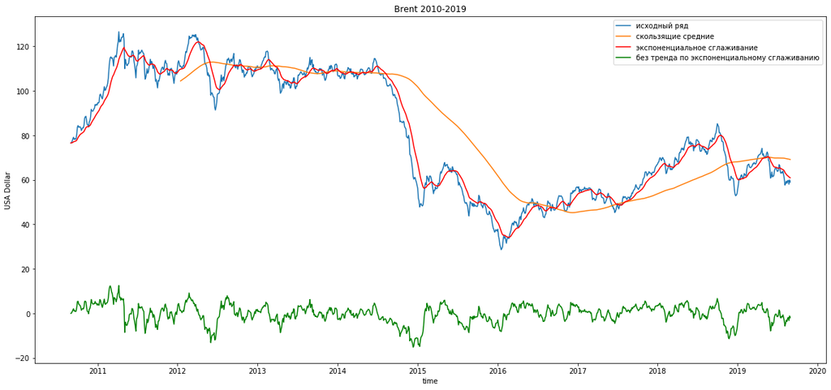

```python
def exponential_smoothing(series, alpha):
    result = [series[0]] # first value is same as series
    for n in range(1, len(series)):
        result.append(alpha * series[n] + (1 - alpha) * result[n-1])
    return result

b_ar_exp_1 = exponential_smoothing(brent_data_3d['Значение'], 0.1)

plt.figure(figsize=(20, 9))
plt.plot(b_s.index, b_s['Значение'], label='исходный ряд')
plt.plot(b_s['Значение'].rolling(window=N2).mean(), label="скользящие средние");

plt.plot(b_s.index,b_ar_exp_1, color = 'red', label="экспоненциальное сглаживание");
plt.plot(b_s.index,b_s['Значение'] - b_ar_exp_1, color = 'green', label="без тренда по экспоненциальному сглаживанию");
plt.xlabel('time')
plt.ylabel('USA Dollar')
plt.legend()
plt.title('Brent 2010-2019')
```

```python
data_exp_1 = exponential_smoothing(brent_data_3d['Значение'], 0.05)
b_ar_exp_1 = pd.DataFrame(data = b_ar_exp_1, index = b_s.index)
```

```python
df= pd.DataFrame(b_ar_exp_1)
df.head()
 # добавили историю на глубину 3 измерения от текущего (р=3)
df['t'] = 0.0
df.iloc[1:,1]=df.iloc[:-1,0].values
df['t1']=0.0
df.iloc[2:,2]=df.iloc[:-2,0].values
df['t2']=0.0
df.iloc[3:,3]=df.iloc[:-3,0].values
df.fillna(0)
# добавили сглаживание (3 вида - просто для коллекции)
df['exp_0_01'] = exponential_smoothing(df[0], 0.01)
df['exp_0_03'] = exponential_smoothing(df[0], 0.03)
df['exp_0_08'] = exponential_smoothing(df[0], 0.08)
# добавим разности - 1-й порядок
df['diff1'] = 0.0
df['diff1'].iloc[1:] = df.iloc[:-1,0].values-df.iloc[1:,0].values
#df.index.names = ['Дата']

df.head()
```

| Дата | 0 | t | t1 | t2 | exp_0_01 | exp_0_03 | exp_0_08 | diff1 |
| --- | --- | --- | --- | --- | --- | --- | --- | --- |
| 2010-09-01 | 76.610000 | 0.000000 | 0.000000 | 0.000000 | 76.610000 | 76.610000 | 76.610000 | 0.000000 |
| 2010-09-04 | 76.619667 | 76.610000 | 0.000000 | 0.000000 | 76.610097 | 76.610290 | 76.610773 | -0.009667 |
| 2010-09-07 | 76.704367 | 76.619667 | 76.610000 | 0.000000 | 76.611039 | 76.613112 | 76.618261 | -0.084700 |
| 2010-09-10 | 76.872430 | 76.704367 | 76.619667 | 76.610000 | 76.613653 | 76.620892 | 76.638594 | -0.168063 |
| 2010-09-13 | 77.101520 | 76.872430 | 76.704367 | 76.619667 | 76.618532 | 76.635311 | 76.675628 | -0.229090 |

```python
df.columns
```

```
Index([0, 't', 't1', 't2', 'exp_0_01', 'exp_0_03', 'exp_0_08', 'diff1'], dtype='object')
```

```python
def mean_absolute_percentage_error(y_true, y_pred):
    y_true, y_pred = np.array(y_true), np.array(y_pred)
    return np.mean(np.abs((y_true - y_pred) / y_true)) * 100
from sklearn.ensemble import GradientBoostingRegressor
from sklearn.preprocessing import StandardScaler

from sklearn.metrics import mean_absolute_error, mean_squared_error, median_absolute_error, r2_score
scl =StandardScaler()
scly =StandardScaler()

# сделаем примеры и модель
def split_data_b( data, split_date ):
    return data.loc[data.index.get_level_values('Дата') <= split_date].copy(), \
           data.loc[data.index.get_level_values('Дата') >  split_date].copy()
```

## h=1

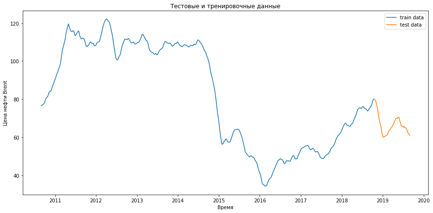

```python
h=1

train_b, test_b = split_data_b( df, '2018-10-10')

X_train_b = train_b.iloc[:-h,:]
y_train_b = train_b[df.columns[0]].values[h:]
X_test_b = test_b.iloc[:-h,:]
y_test_b = test_b[df.columns[0]].values[h:]


plt.figure( figsize=( 15, 7 ))
plt.xlabel('Время')
plt.ylabel('Цена нефти Brent')
plt.plot(train_b.index.get_level_values('Дата'),train_b[df.columns[0]], label='train data' )
plt.plot(test_b.index.get_level_values('Дата'),test_b[df.columns[0]], label='test data')
plt.title( 'Тестовые и тренировочные данные' )
plt.legend()
plt.show()
```

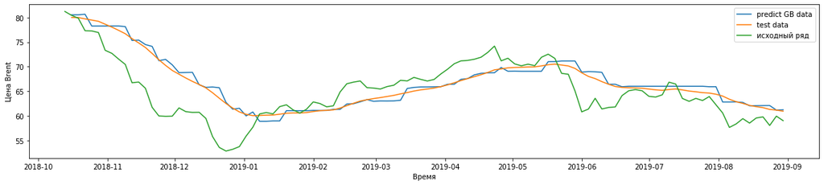

```
ошибка градиентного бустинга :   0.9668016030711912 %
```

```python
#h=1
model_gb = GradientBoostingRegressor(max_depth=15, random_state=0, n_estimators=100)
model_gb.fit( X_train_b, y_train_b )
X_test_pred_gb = model_gb.predict(X_test_b)

plt.figure( figsize=( 20, 4 ))

plt.xlabel('Время')
plt.ylabel('Цена Brent')
plt.plot(test_b.index[1:],X_test_pred_gb, label='predict GB data' )
plt.plot(test_b.index[1:],y_test_b, label='test data')
plt.plot(b_s.loc['2018-10-11':].index, b_s.loc['2018-10-11':]['Значение'], label='исходный ряд')

plt.legend()
plt.show()

er_g = mean_absolute_percentage_error(y_true=y_test_b, y_pred=X_test_pred_gb)

print('ошибка градиентного бустинга :  ', er_g, '%')
```

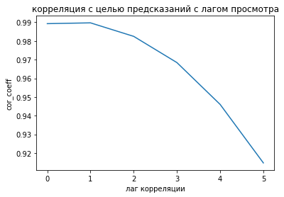

```python
lag=5
p_cor=[np.corrcoef( y_test_b, X_test_pred_gb)[1,0]]
for i in range(lag):
    c=np.corrcoef( y_test_b[:-(i+1)], X_test_pred_gb[(i+1):])[1,0]
    p_cor.append(c)

plt.plot(np.array(p_cor) )
plt.xlabel('лаг корреляции')
plt.ylabel('cor_coeff')
plt.title('корреляция с целью предсказаний с лагом просмотра')
plt.show()
```

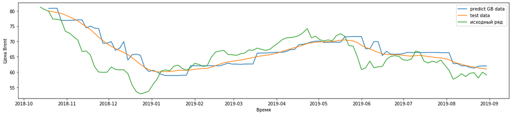

```
ошибка градиентного бустинга :   1.523159972351661 %
```

```python
h=2
X_train_b = train_b.iloc[:-h,:]
y_train_b = train_b[df.columns[0]].values[h:]
X_test_b = test_b.iloc[:-h,:]
y_test_b = test_b[df.columns[0]].values[h:]

model_gb.fit( X_train_b, y_train_b )
X_test_pred_gb = model_gb.predict(X_test_b)

plt.figure( figsize=( 20, 4 ))

plt.xlabel('Время')
plt.ylabel('Цена Brent')
plt.plot(test_b.index[h:],X_test_pred_gb, label='predict GB data' )
plt.plot(test_b.index[h:],y_test_b, label='test data')
plt.plot(b_s.loc['2018-10-11':].index, b_s.loc['2018-10-11':]['Значение'], label='исходный ряд')

plt.legend()
plt.show()

er_g = mean_absolute_percentage_error(y_true=y_test_b, y_pred=X_test_pred_gb)

print('ошибка градиентного бустинга :  ', er_g, '%')
```

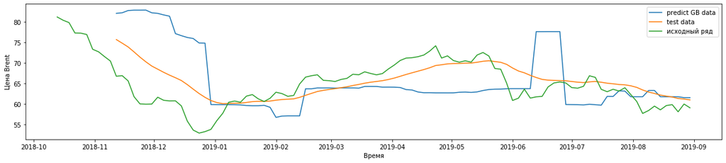

```
ошибка градиентного бустинга :   7.287132529797812 %
```

```python
h=10
X_train_b = train_b.iloc[:-h,:]
y_train_b = train_b[df.columns[0]].values[h:]
X_test_b = test_b.iloc[:-h,:]
y_test_b = test_b[df.columns[0]].values[h:]

model_gb.fit( X_train_b, y_train_b )
X_test_pred_gb = model_gb.predict(X_test_b)

plt.figure( figsize=( 20, 4 ))

plt.xlabel('Время')
plt.ylabel('Цена Brent')
plt.plot(test_b.index[h:],X_test_pred_gb, label='predict GB data' )
plt.plot(test_b.index[h:],y_test_b, label='test data')
plt.plot(b_s.loc['2018-10-11':].index, b_s.loc['2018-10-11':]['Значение'], label='исходный ряд')

plt.legend()
plt.show()

er_g = mean_absolute_percentage_error(y_true=y_test_b, y_pred=X_test_pred_gb)

print('ошибка градиентного бустинга :  ', er_g, '%')
```

## Задание

Модель авторегрессии с горизонтом прогноза 1 (т.е. считаем на один шаг вперед) работает замечательно на всем интервале теста. Значение ошибки для нее не превышает 1%.

С увеличением горизонта прогноза растет ошибка

## Задание

1. Попробуйте предположить характер ряда (стационарный или нет, с трендом, с сезоном, с циклом) для рядов из списка и аргументируйте свой ответ (одна строка):

а) Изменение температуры за окном :).

б) Количество денег, которые тратят покупатели в интернет магазине.

в) Вес растущего котенка.

г) Прирост объема деревьев в лесу от времени

## Ответ

```python
а) стационарный, сезонный с присутствием циклов
б) стационарный, сезонный
в) нестационарный с трендом, циклический
г) нестационарный с трендом
```